# Monte Carlo Methods

Chen, Yong, yongc2

Saturday, October 6, 2018

## Exercise 1

**Sampling via special transformation.**

**(a)** Suppose we can only sample from $Unif[0,1]$. $k=3$. Design an algorithm to simulate $\chi^2$ distribution with $2k$ freedom via general transformation method.  
1. Generate $U_{1}...U_{k}$~ U(0,1);  
2. Compute $X=-log(U)$;  
3. result=$2\sum_{i=1}^{k}X_{i}$~$\chi^2_{2k}$

**(b)** Write an R code to generate sample following chi-squared distribution based on your designed algorithm in the previous part, with $n=2000$ sample size. Then, estimate expected value of this chi-squared distribution. Check if your estimates match the theoretically expected value of chi-squared distribution or not.

```r
n=2000
u=matrix(runif(n*3),n,3)
y=2*rowSums(-log(u))
mean(y)  #estimated expected value
```

```
## [1] 6.003
```

```r
mean(rchisq(n,df=6)) #theoretically expected value
```

```
## [1] 6.137
```

**(a)**
$$\int_{0}^{2} sin(x^2) dx$$

```r
m=10000
x=runif(m,0,2)
gx=sin(x^2)
mean(gx)*2
```

```
## [1] 0.7904
```

**(b)**
$$\int_{0}^{1}\int_{0}^{1} e^{-(x+y)^3}(x+y) dx dy$$

```r
m=10000
x=runif(m,0,1)
y=runif(m,0,1)
gx2=exp(1)^(-(x+y)^3)*(x+y)
mean(gx2)*1
```

```
## [1] 0.2918
```

**(c)**
$$\int_{0}^{5}\int_{0}^{2} e^{-(x+y)^3}(x+y) dx dy$$

```r
m=10000
x=runif(m,0,2)
y=runif(m,0,5)
gx2=exp(1)^(-(x+y)^3)*(x+y)
mean(gx2)*10
```

```
## [1] 0.3396
```

## Exercise 3:

1. Implement this algorithm and generate 20000 random samples.
2. Output a histogram of these samples and overlay the density of the original distribution.

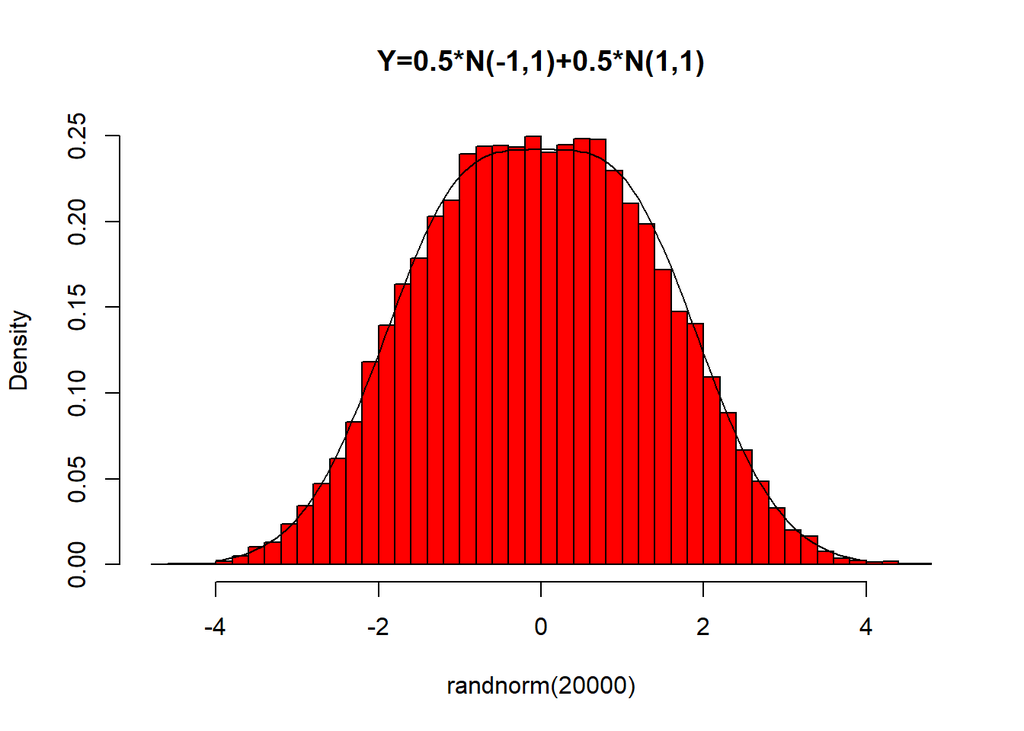

```r
randnorm=function(n){
  fg=function(x){
  (exp(-((x+1)^2)/2)+exp(-((x-1)^2)/2))*pi*(1+x^2)*(1/(2*sqrt(2*pi))) # indicates f(x)/g(x)
}
  M=fg(2) #when x=2, f(x)/g(x) reachs its maximum
  k=0
  j=0
  z=rep(0,times=n)
  while(k<n){
    x=tan(pi*(runif(1)-0.5)) #cdf of cauchy distribulation
    u=runif(1)
    if(u<=fg(x)/M){
      k=k+1
      z[k]=x
    }
    j=j+1
  }
  return(z)
}

hist(randnorm(20000),freq=F,col="red",breaks=50,main='Y=0.5*N(-1,1)+0.5*N(1,1)')
x=seq(-4,4,.1)
curve(0.5*dnorm(x,-1,1)+0.5*dnorm(x,1,1),xlim=c(-4,4),add=TRUE) #density curve of the original distribulation
```

## Exercise 4

```r
k=1000
u=runif(k,0,1)
f=exp(u)
I1=mean(f)
I1
```

```
## [1] 1.721
```

**(b)** Describe an inverse transform algorithm to sample from the proposed distribution $g(x)$.  
we know that $g(x)=\frac{5}{2}x^{3/2}$, we can derive that cdf of g(x) $G(x)=x^{5/2}$ and compute inverse $x=u^{2/5}$  
1. Generate U~U(0,1);  
2. Plug U in and compute $x=u^{2/5}$.

**(c)** Implmement your algorithm to get 1000 samples from $g(x)$, $(X_1, X_2, \ldots, X_{1000})$.

```r
u=runif(1000,0,1)
x=u^(2/5)
```

```r
I2=mean(exp(x)/(2.5*x^(-1.5)))
I2
```

```
## [1] 0.5578
```

## Exercise 5

**Prediction of closing prices** 1. Simulate a sample path of stock price $S(t)$ for 20 days and plot it with line type. (with R code)

```r
v=0.0009
i=2
k=20
s=numeric(k+1)
s[1]=20
while (i<k+2) {
  r=rnorm(1,0,v)
  s[i]=exp(r+log(s[i-1]))
  i=i+1
}
s=s[-1]
s
```

```
##  [1] 19.99 20.00 19.97 19.95 19.95 19.97 19.94 19.95 19.91 19.91 19.90 19.90
## [13] 19.90 19.90 19.92 19.92 19.93 19.91 19.88 19.89
```

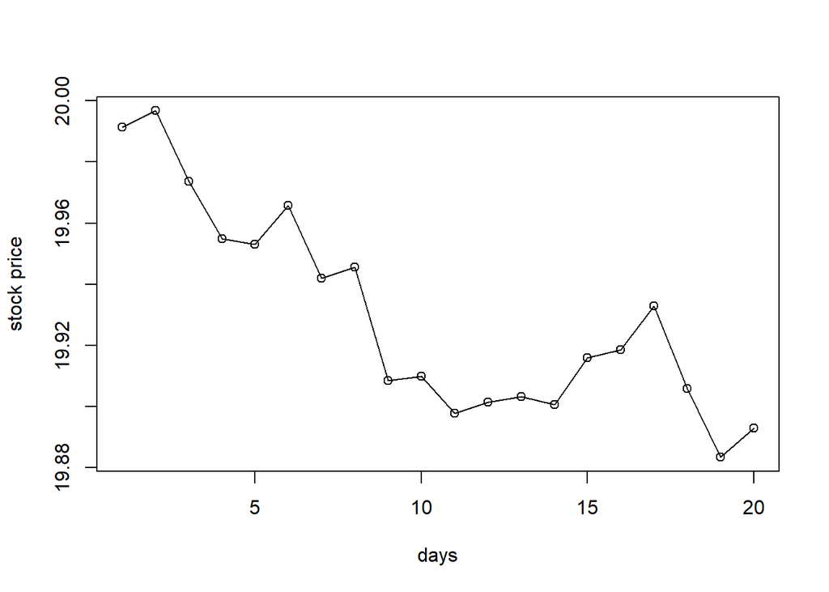

```r
plot(s,xlab='days',ylab='stock price')
lines(s)
```

2. Estimate the expected closing price at day $20$: $E(S(20))$ based on $100000$ sample path. Meanwhile, report its upper and lower 95th percentiles.

```r
n=100000
s20=numeric(n)
price=function(){ #create a function computing S(20)
  v=0.0009
  i=2
  k=20
  s=numeric(k+1)
  s[1]=20
  while (i<k+2) {
    r=rnorm(1,0,v) #generate sample from normal(o,v)
    s[i]=exp(r+log(s[i-1])) #compute s(t)
    i=i+1
  }
  return(s[length(s)])
}

for(i in 1:n){
  s20[i]=price()
}
mean(s20)
```

```
## [1] 20
```

```r
quantile(s20,c(0.05,0.95))
```

```
##    5%   95%
## 19.87 20.13
```

## Exercise 6

```r
u=runif(10000,0,pi/3)
x_hat=mean(sin(u))*(pi/3)
x=-cos(pi/3)+cos(0)
x_hat #estimator
```

```
## [1] 0.5038
```

```r
x #true value
```

```
## [1] 0.5
```

```r
abs(x_hat-x) #residual
```

```
## [1] 0.00376
```

##Exercise 7

```r
n=10000
u=runif(n,0,0.5) #sample from Uniform(0,0.5)
theta_hat1=mean(exp(-u))*0.5
(0.5-0)^2*var(exp(-u))/n #variance
```

```
## [1] 3.218e-07
```

```r
r=rexp(n,1) #sample from Exp(1)
theta_hat2=mean(r<0.5) #monte carlo
var(r<0.5)/n #variance
```

```
## [1] 0.00002375
```

```r
abs((0.5-0)^2*var(exp(-u))/n-var(r<0.5)/n)  #error
```

```
## [1] 0.00002343
```

Samples from Uniform distribution has lower variance, because from interval 0-0.5, Exp(1) only contains portion of its distribution, therefore samples from Exponential distribution will be larger.

##Exercise 8

```r
mybetacdf=function(x){
  u=runif(10000,0,x)
  g=30*(u^2)*(1-u)^2
  cdf=mean(g)*x
  return(cdf)
}
Fx=seq(0.1,0.9,0.1)
result=numeric(length(Fx))
for (i in 1:length(Fx)){
  result[i]=mybetacdf(Fx[i])
}
result #Monte Carlo estimator
```

```
## [1] 0.008556 0.057557 0.162149 0.316126 0.501119 0.685016 0.838087 0.942933
## [9] 0.990266
```

```r
pbeta(Fx,3,3) #true value
```

```
## [1] 0.00856 0.05792 0.16308 0.31744 0.50000 0.68256 0.83692 0.94208 0.99144
```

Compared the result and the true value, we can know they are very close to each other.

##Exercise 9 + Exercise 10 Pick $f_1=\frac{e^{-x^2/2}}{\sqrt{2\pi}}I_{\{1,\infty\}}$

$f_2=e^{-x}I_{\{1,\infty\}}$

```r
m=10000
X=rnorm(m,0,1)
g=function(x){x^2/sqrt(2*pi)*exp(-x^2/2)*(x > 1)}
mean(g(X)/dnorm(X)*(X>1)) #f1 is pdf of Normal(0,1)
```

```
## [1] 0.3972
```

```r
Y=rexp(m,1)
g=function(x){x^2/sqrt(2*pi)*exp(-x^2/2)*(x > 1)}
mean(g(Y)/dexp(Y)*(Y>1)) #f2 is the pdf of standard exponential distribution
```

```
## [1] 0.4079
```